# Problem set 6 key: Consumer-resource & competition

```r
library(package = "deSolve")
library(package = "phaseR")
```

Welcome back from break! I hope that you are all well rested and eager to take on the second half of the term! I want to note that I will be scaling back the problem sets a bit so that you may allocate more of your time to the remodeling project for this second half of the course. That being written, I ask that you please complete and turn in a knitted (.html and optional .Rmd) copy of your assignment to Filer on time. It is important to me to post the problem set keys soon after the due date so that way people have access to the key and can checks their answers. The sooner after people see keys, the better reinforced the learning. Thank you for your cooperation.

These questions all require the same parameter values, but present the results differently. Nothing technically is new here, but you are essentially graphically showing the same result 3 different ways.

## Time series

1.1. First, write out, in $\LaTeX$, the Rosenzweig-MacArthur predator-prey/consumer-resource model. Remember the equations are separated in the book (for some unknown and mildly-annoying reason), but can be found as the first equation on the top of page 166 and the first equation on page 165.

1.2. Second, using the Rosenzweig-MacArthur predator-prey/consumer-resource model, I ask that you show 3 time series; each with a different dynamical behavior: (1) stable, prey only equilibrium, (2) stable coexistence of prey and predators, and (3) unstable (spiral) predator and prey populations. Make a time sequence until 100 units of time and use the parameter values:

| Parameter | Symbol | Value |
| --- | --- | --- |
| Intrinsic rate of grow of prey | $r$ | 0.5 |
| Maximum consumption rate of prey | $c$ | 2 |
| Half-saturation constant | $g$ | 10 |
| Maximum consumption and conversion rate of prey to pre | $b$ | 1.5 |
| Density-independent death rate of predators | $m$ | 1 |

The way I would like you to create the 3 different dynamical behaviors is to modify the carrying capacity. Just plug in various numbers until you graphically see the different behaviors. Note that increasing the carrying capacity in this model tends to destabilize the populations; hence, the *paradox of enrichment* you read about before break.

Last, make sure to plot all three in the same graph, by setting up the plotting parameters (e.g., `par(mfrow = c(1, 3), mar = c(4.5, 4.5, 0.5, 0.5))`) and add the chunk option (between the curly brackets at the top of the code chunk) `fig.dim = c(8, 3)` to set the width and height of the figure once it’s knitted.

> 1.1.

> ```
> $$
> \begin{aligned}
> \frac{\mathrm{d}V}{\mathrm{d}t} &= rV\left(\frac{K - V}{K}\right) - \frac{cVP}{g + V} \\
> \frac{\mathrm{d}P}{\mathrm{d}t} &= \frac{bVP}{g + V} - mP
> \end{aligned}
> $$
> ```

> $$\begin{aligned}
> \frac{\mathrm{d}V}{\mathrm{d}t} &= rV\left(\frac{K - V}{K}\right) -
> \frac{cVP}{g + V} \\
> \frac{\mathrm{d}P}{\mathrm{d}t} &= \frac{bVP}{g + V} - mP
> \end{aligned}$$

> 1.2.

[figure not shown]

> ```r
> MR <- function(t, y, parms) {
>  with(as.list(c(y, parms)), {
>    dVdt <- r*V*(K-V)/K - c*V*P/(g + V)
>    dPdt <- b*V*P/(g + V) - m*P
>    return(list(c(dVdt, dPdt)))
>  })
> }
>
> parm_vec_eq <- c(r = 0.5, K = 15, c = 2, g = 10, b = 1.5, m = 1)
> parm_vec_stab <- c(r = 0.5, K = 30, c = 2, g = 10, b = 1.5, m = 1)
> parm_vec_unstab <- c(r = 0.5, K = 100, c = 2, g = 10, b = 1.5, m = 1)
>
> time_vec <- seq(from = 0, to = 100, length.out = 1000)
> N0 <- c("V" = 19, "P" = 5.8)
>
> MRode_prey <- ode(y = N0, times = time_vec, func = MR, parms = parm_vec_eq)
> MRode_stab <- ode(y = N0, times = time_vec, func = MR, parms = parm_vec_stab)
> MRode_unstab <- ode(y = N0, times = time_vec, func = MR, parms = parm_vec_unstab)
> y_max_prey <- max(MRode_prey[,2:3], na.rm = T)
> y_max_stab <- max(MRode_stab[,2:3], na.rm = T)
> y_max_unstab <- max(MRode_unstab[,2:3], na.rm = T)
>
> par(mfrow = c(1, 3), mar = c(4.5, 4.5, 0.5, 0.5))
> plot(x = MRode_prey[,1], y = MRode_prey[,2], type = "l", xlab = "Time", ylab = "Prey (blue) and predator (red) density", col = "red", ylim = c(0, y_max_prey), las = 1)
>  lines(x = MRode_prey[,1], y = MRode_prey[,3], col = "blue")
>
> plot(x = MRode_stab[,1], y = MRode_stab[,2], type = "l", xlab = "Time", ylab = "Prey (blue) and predator (red) density", col = "red", ylim = c(0, y_max_stab), las = 1)
>  lines(x = MRode_stab[,1], y = MRode_stab[,3], col = "blue")
>
>  plot(x = MRode_unstab[,1], y = MRode_unstab[,2], type = "l", xlab = "Time", ylab = "Prey (blue) and predator (red) density", col = "red", ylim = c(0, y_max_unstab), las = 1)
>  lines(x = MRode_unstab[,1], y = MRode_unstab[,3], col = "blue")
> ```

## Phase plane

2. I would like you to make phase planes for the time series above. Plot the (1) vector field, (2) nullclines, and (3) the trajectory (with a point where your populations begin at time = 0 and a curve using `lines()` for the prey and predator populations) for each of the 3 graphs. That’s it!

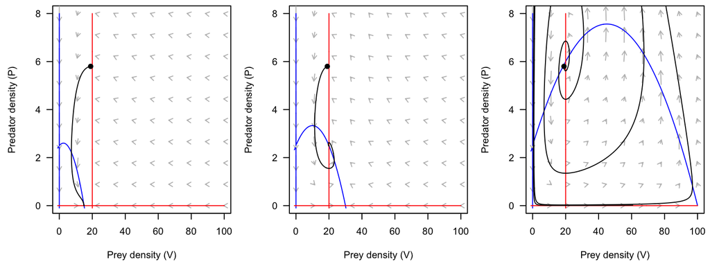

> ```r
> par(mfrow = c(1, 3), mar = c(4.5, 4.5, 0.5, 0.5))
>
> plot(x = NA, type = "n", xlim = c(0,100), ylim = c(0, 8), xlab = "Prey density (V)", ylab = "Predator density (P)", las = 1)
> trash <- flowField(deriv = MR, xlim = c(0,100), ylim = c(0, 8), parameters = parm_vec_eq, points = 10, add = T, state.names = c("V", "P"), las = 1)
> trash <- nullclines(deriv = MR, xlim = c(-1,100), ylim = c(-0.1, 8), parameters = parm_vec_eq, add.legend = F, col = c("blue", "red"), state.names = c("V", "P"), points = 200)
> points(x = MRode_prey[1, 2], y = MRode_prey[1, 3], pch = 19)
> lines(x = MRode_prey[, 2], y = MRode_prey[, 3])
>
> plot(x = NA, type = "n", xlim = c(0,100), ylim = c(0, 8), xlab = "Prey density (V)", ylab = "Predator density (P)", las = 1)
> trash <- flowField(deriv = MR, xlim = c(0,100), ylim = c(0, 8), parameters = parm_vec_stab, points = 10, add = T, state.names = c("V", "P"))
> trash <- nullclines(deriv = MR, xlim = c(-1,100), ylim = c(-0.1, 8), parameters = parm_vec_stab, add.legend = F, col = c("blue", "red"), state.names = c("V", "P"), points = 200)
> points(x = MRode_stab[1, 2], y = MRode_stab[1, 3], pch = 19)
> lines(x = MRode_stab[, 2], y = MRode_stab[, 3])
>
> plot(x = NA, type = "n", xlim = c(0,100), ylim = c(0, 8), xlab = "Prey density (V)", ylab = "Predator density (P)", las = 1)
> trash <- flowField(deriv = MR, xlim = c(0,100), ylim = c(0, 8), parameters = parm_vec_unstab, points = 10, add = T, state.names = c("V", "P"))
> trash <- nullclines(deriv = MR, xlim = c(-1,100), ylim = c(-0.1, 8), parameters = parm_vec_unstab, add.legend = F, col = c("blue", "red"), state.names = c("V", "P"), points = 200)
> points(x = MRode_unstab[1, 2], y = MRode_unstab[1, 3], pch = 19)
> lines(x = MRode_unstab[, 2], y = MRode_unstab[, 3])
> ```